# Scurrying Secrets: Unraveling the Tapestry of Squirrel Activity

we could also name this “Acorn Adventures: Unraveling the Tapestry of Squirrel Activity”

```r
squirrel_census =
  read_csv("data/clean_squirrel_2018.csv") |>
  janitor::clean_names()
```

Squirrels are dynamic creatures with a secret language. In a bustling environment like New York City, these animals use unique signals to communicate with each other, other animals, and us.

First, let’s take a look at squirrel sounds.

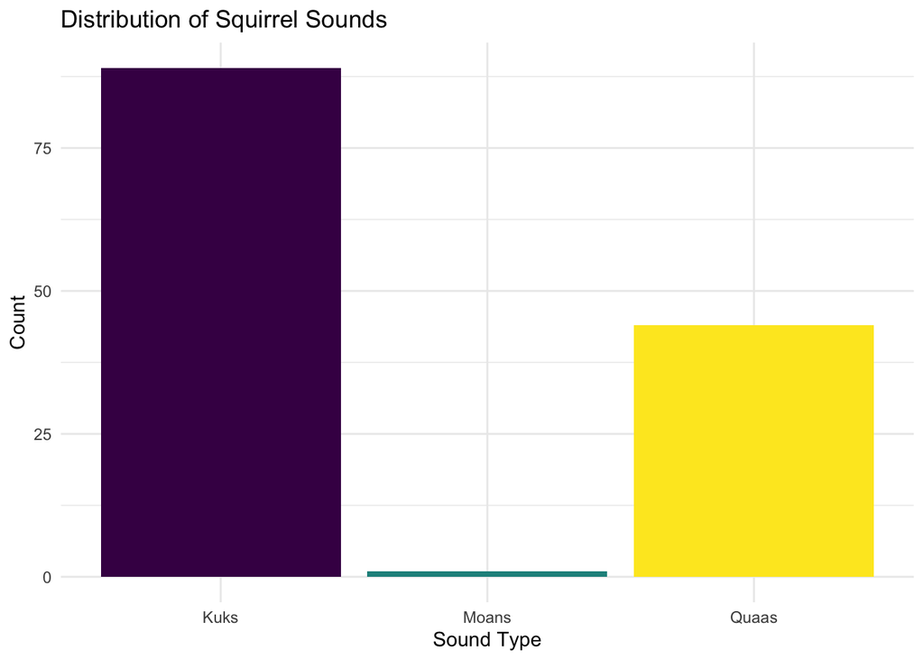

```r
sounds_summary = data.frame(
  Sound = c("Kuks", "Quaas", "Moans"),
  Count = c(sum(squirrel_census[["kuks"]], na.rm = TRUE),
            sum(squirrel_census[["quaas"]], na.rm = TRUE),
            sum(squirrel_census[["moans"]], na.rm = TRUE))
)

# Squirrel sounds distribution
ggplot(sounds_summary, aes(x = Sound, y = Count, fill = Sound)) +
  geom_bar(stat = "identity", show.legend = FALSE) +
  scale_fill_viridis(discrete = TRUE) +
  theme_minimal() +
  labs(title = "Distribution of Squirrel Sounds", x = "Sound Type", y = "Count")
```

### Hypothesis Testing

We’re interested in investigating the relationship between `shift` (morning or afternoon sighting) and the locations of the squirrels (grounf plane, or above ground)

##### State Hypotheses

- H0: There is no significant association between shift and location
- H1: There is a significant association between shift and location

##### Assumptions

The Chi-Square Test of Independence assumes that

1. Observations must be independent
2. Data must be categorical in nature
3. The expected frequency in each cell in the contingency table should be greater than 5
4. Data should be collected via random sampling
5. The overall sample size should be large

##### Create contingency table

```r
contingency_table =
  squirrel_census |>
  select(shift, location) |>
  summarise_all(factor) |>
  table()
```

##### Conduct Test

```r
chi_square_result = chisq.test(contingency_table)

print(chi_square_result)
```

```
##
##  Pearson's Chi-squared test with Yates' continuity correction
##
## data:  contingency_table
## X-squared = 30.835, df = 1, p-value = 2.809e-08
```

##### Final Conclusion

At the 0.05 level of significance, there is evidence to suggest that the distribution of locations is not independent of the shift; in other words, there is a significant association between the time of day and the location where squirrels are observed.

This may mean that squirrels exhibit different location preferences or behaviors during the morning (AM) compared to the afternoon (PM). Squirrels are known to be diurnal animals, so the results of the chi-square test serves as additional evidence. Since squirrels have been observed to be active more during dawn and dusk, this makes a lot of sense.

#### What About a Logistic Regression Model?

We want to see if we can create a logistic regression model to predict the likelihood of a squirrel being observed on the “ground plane,” based on time of squirrel sighting (`shift`) and the following behavioral variables: `running`, `chasing`, `climbing`, `eating` and `foraging`.

##### Fitting a Model

```r
set.seed(1)

squirrel_census_df =
  squirrel_census|>
  mutate_all(as.factor)

fit_logistic =
  squirrel_census |>
  glm(location == "Ground Plane" ~ shift + running + chasing + climbing + eating + foraging,
                    data = _,
                    family = binomial())
```

Let’s tidy up the output.

```r
fit_logistic |>
 broom::tidy() |>
  mutate(OR = exp(estimate)) |>
  select(term, estimate, OR, p.value) |>
  knitr::kable()
```

| term | estimate | OR | p.value |
| --- | --- | --- | --- |
| (Intercept) | 0.6343567 | 1.8858085 | 0.0000002 |
| shiftPM | 0.4034906 | 1.4970411 | 0.0003493 |
| runningTRUE | 0.7394408 | 2.0947638 | 0.0000000 |
| chasingTRUE | -0.1335987 | 0.8749411 | 0.4478169 |
| climbingTRUE | -2.8894573 | 0.0556064 | 0.0000000 |
| eatingTRUE | 0.3728613 | 1.4518829 | 0.0057817 |
| foragingTRUE | 1.8236542 | 6.1944529 | 0.0000000 |

Based on this output, we see that almost all of our results are statistically significant at the 5% level. Woohoo! Let’s look at some model diagnostics.

```r
squirrel_census |>
  modelr::add_predictions(fit_logistic) |>
  mutate(fitted_prob = boot::inv.logit(pred))
```

```
## # A tibble: 2,824 × 37
##        x     y unique_squirrel_id hectare shift date
##    <dbl> <dbl> <chr>              <chr>   <chr> <date>
##  1 -74.0  40.8 13E-AM-1017-05     13E     AM    2018-10-17
##  2 -74.0  40.8 36H-AM-1010-02     36H     AM    2018-10-10
##  3 -74.0  40.8 33F-AM-1008-02     33F     AM    2018-10-08
##  4 -74.0  40.8 21C-PM-1006-01     21C     PM    2018-10-06
##  5 -74.0  40.8 11D-AM-1010-03     11D     AM    2018-10-10
##  6 -74.0  40.8 20B-PM-1013-05     20B     PM    2018-10-13
##  7 -74.0  40.8 22F-PM-1014-06     22F     PM    2018-10-14
##  8 -74.0  40.8 36I-PM-1007-01     36I     PM    2018-10-07
##  9 -74.0  40.8 5C-PM-1010-09      05C     PM    2018-10-10
## 10 -74.0  40.8 7H-AM-1006-05      07H     AM    2018-10-06
## # ℹ 2,814 more rows
## # ℹ 31 more variables: hectare_squirrel_number <dbl>, age <chr>,
## #   primary_fur_color <chr>, highlight_fur_color <chr>,
## #   combination_of_primary_and_highlight_color <chr>, color_notes <chr>,
## #   location <chr>, above_ground_sighter_measurement <chr>,
## #   specific_location <chr>, running <lgl>, chasing <lgl>, climbing <lgl>,
## #   eating <lgl>, foraging <lgl>, other_activities <chr>, kuks <lgl>, …
```

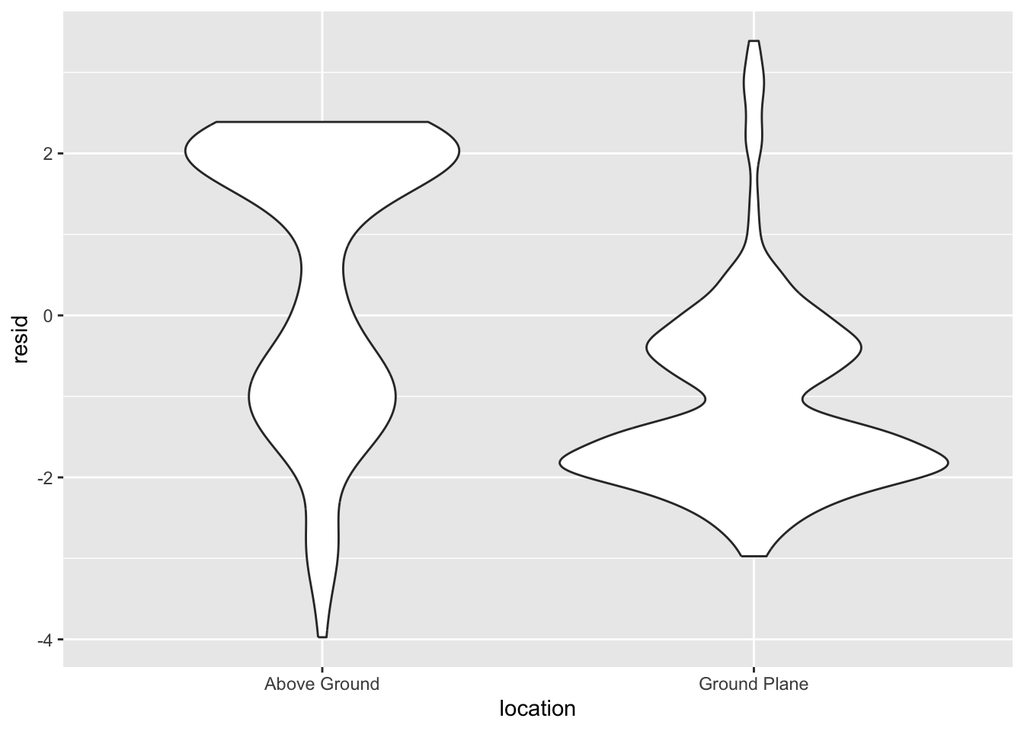

```r
squirrel_census |>
  modelr::add_residuals(fit_logistic) |>
  ggplot(aes(x = location, y = resid)) +
  geom_violin()
```

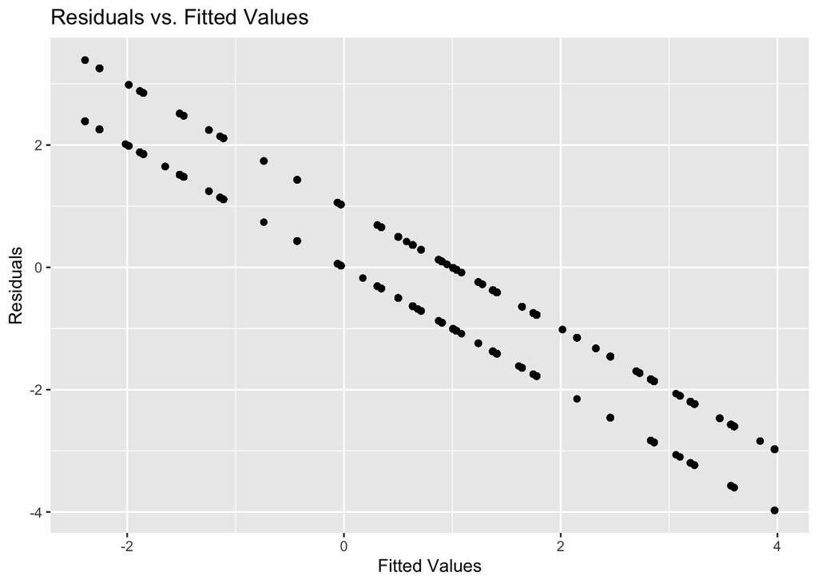

```r
squirrel_census |>
  modelr::add_predictions(fit_logistic) |>
  modelr::add_residuals(fit_logistic) |>
  ggplot(aes(x = pred, y = resid)) +
  geom_point() +
    labs(title = "Residuals vs. Fitted Values",
       x = "Fitted Values",
       y = "Residuals")
```

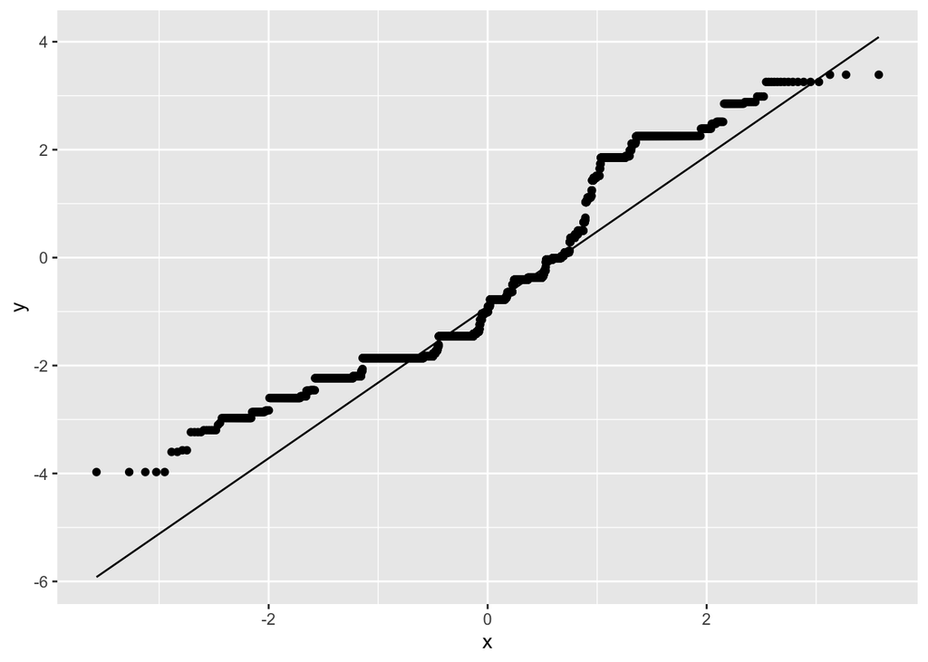

```r
squirrel_census |>
  modelr::add_residuals(fit_logistic) |>
  ggplot(aes(sample = resid)) +
  stat_qq() +
  stat_qq_line()
```

From the QQPlot and our residuals plot, this model really isn’t too awful.